# TEMA 19

### 5.2.2 Forma unui nod

De asemenea, pachetul statnet ofera optiunea de a ilustra grafic nodurile cu ajutorul mai multor forme. Acest lucru devine practic atunci cand exista un numar redus de noduri in reteaua pe care vrem sa o reprezentam. Tipul formei geometrice dorite este specificat prin intermediul numarului de laturi ale sale.

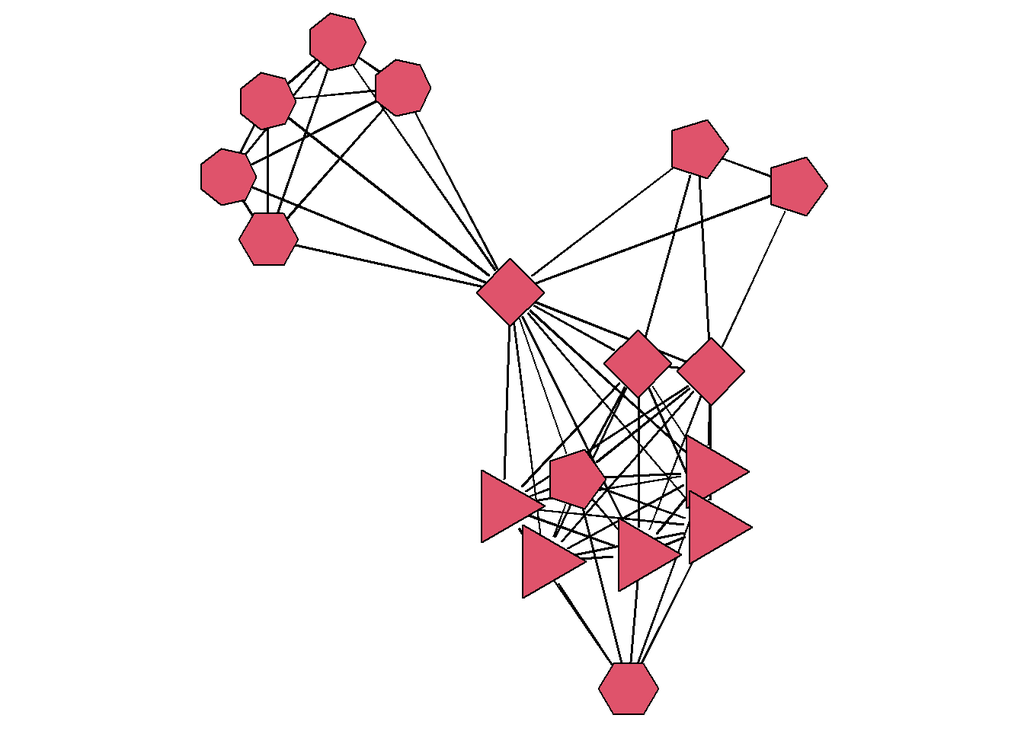

```r
op <- par(mar=c(0,0,0,0))
rolecat <- as.factor(get.vertex.attribute(Bali,"role"))
sidenum <- 3:7
plot(Bali,usearrows=FALSE,vertex.cex=4,
displaylabels=F,vertex.sides=sidenum[rolecat])
```

### 5.2.3 Marimea unui nod

Marimea nodurilor unei retele poate fi ajustata cu ajutorul optiunii vertex.cex, disponibila atat la functia plot, cat si la gplot. Nodurile ar trebui sa fie suficient de mari incat sa fie vizibile, insa suficient de mici cat sa nu exista suprapuneri repetate, care sa incurce analiza figurii. Un exemplu cu diverse marimi este disponibil mai jos:

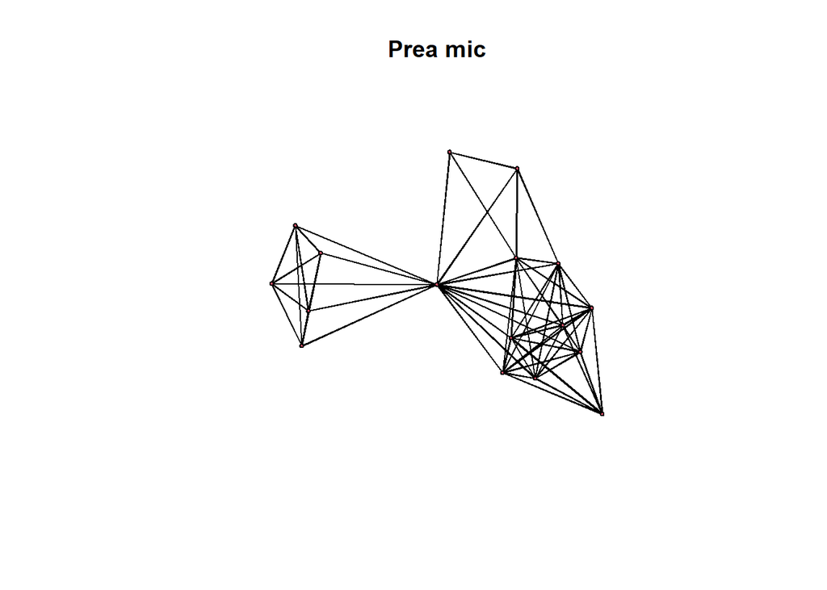

```r
plot(Bali,vertex.cex=0.5,main="Prea mic")
```

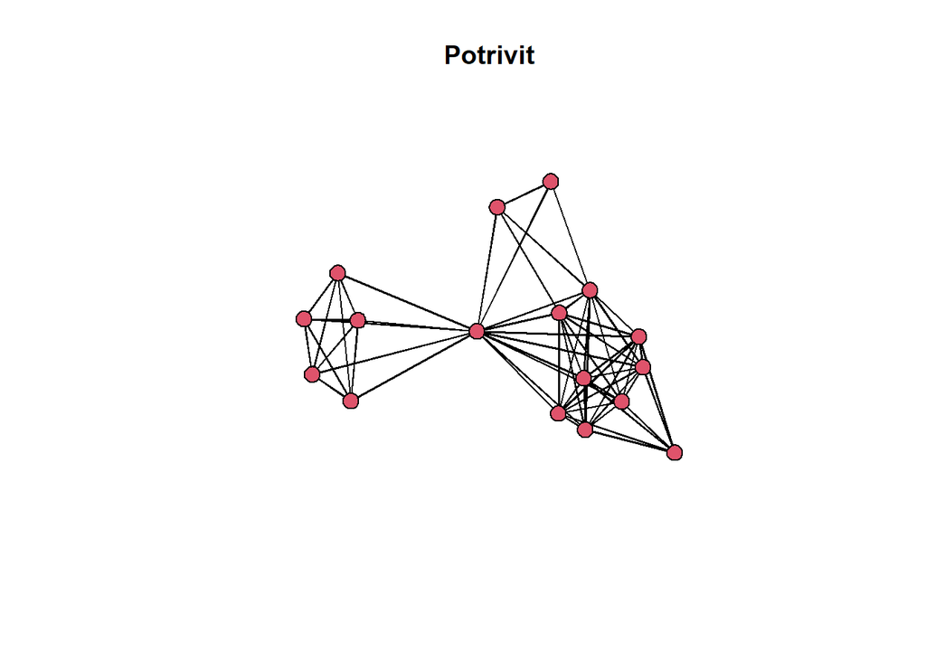

```r
plot(Bali,vertex.cex=2,main="Potrivit")
```

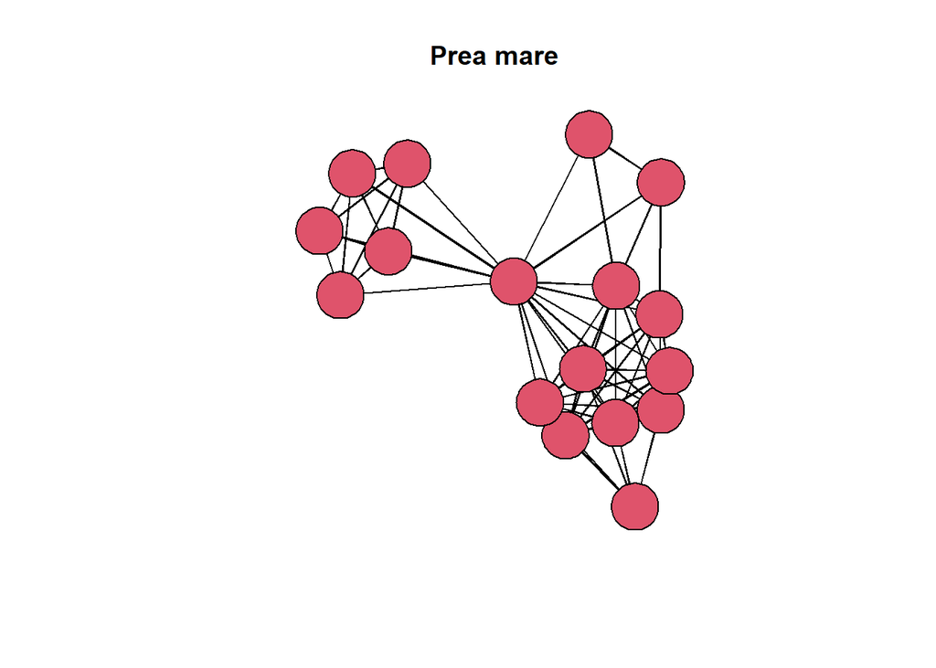

```r
plot(Bali,vertex.cex=6,main="Prea mare")
```

Marimea unui nod poate comunica aspecte importante ale retelei, spre exemplu: nivelul de centralitate al nodurilor. Pentru a sugera pozitia nodurilor din retea (aflate la periferie/centrate), ne putem folosi de marimea lor (nodurile din centru sa fie mai mari). Mai jos am printat o proprietate a nodurilor din reteaua Bali:

```
deg <- degree(Bali,gmode="graph")
deg
## [1] 9 4 9 15 9 10 3 9 9 5 5 5 5 5 9
## [16] 6 9
```

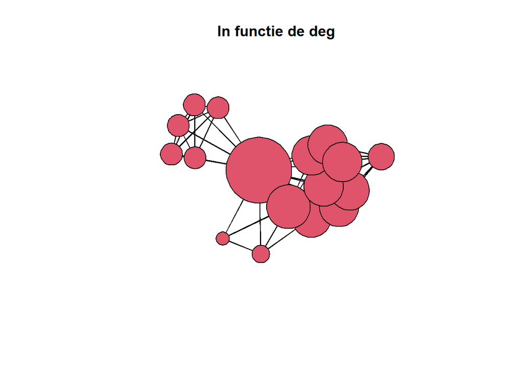

```r
deg <- degree(Bali,gmode="graph")
plot(Bali,usearrows=T,vertex.cex=deg,main="In functie de deg")
```

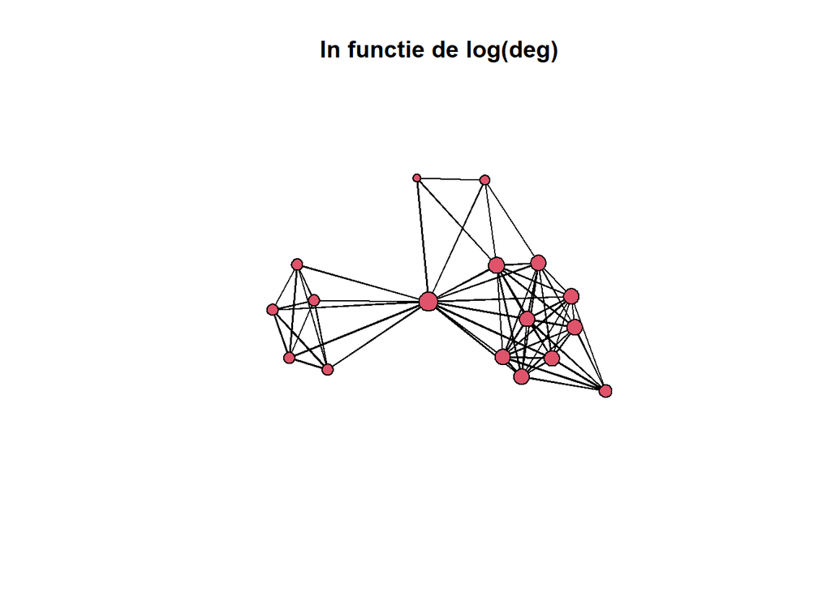

```r
plot(Bali,usearrows=FALSE,vertex.cex=log(deg),
main="In functie de log(deg)")
```

Alte exemple de ajustare a dimensiunii nodurilor: folosind proprietatea “cls” (closeness), pe care o multiplicam cu o valoare oarecare (de exemplu 4). Valorile initiale ale acestei proprietati sunt mult prea mici, motiv pentru care nodurile ar fi reprezentate foarte mici. Codul este disponbibil mai jos:

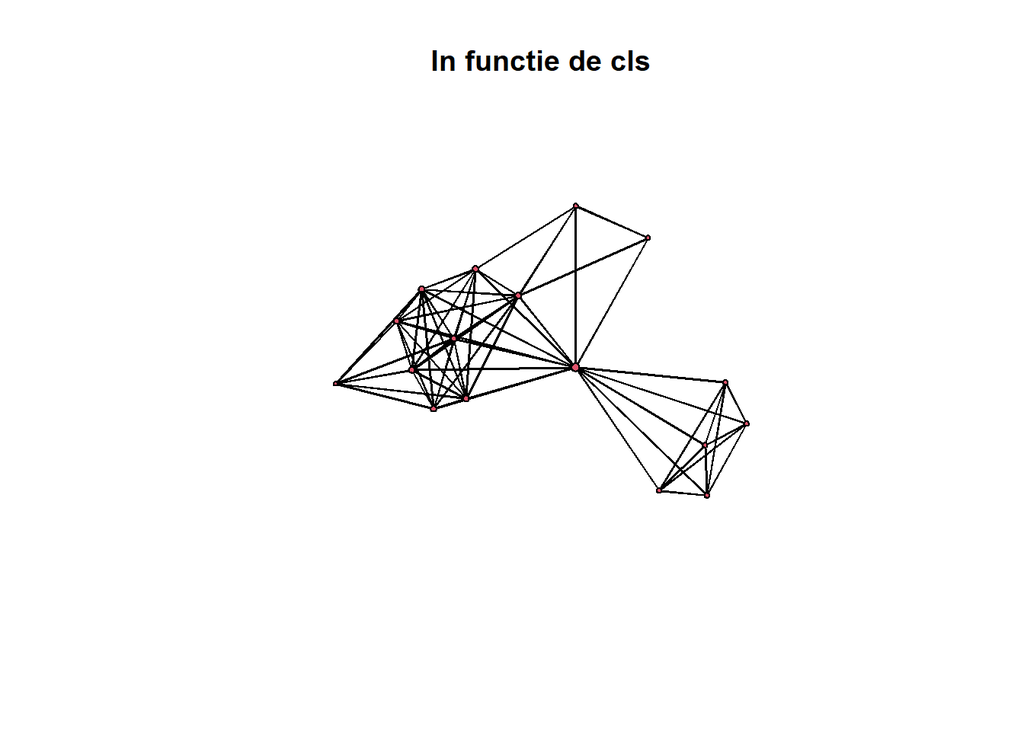

```r
cls <- closeness(Bali,gmode="graph")
plot(Bali,usearrows=T,vertex.cex=cls,main="In functie de cls")
```

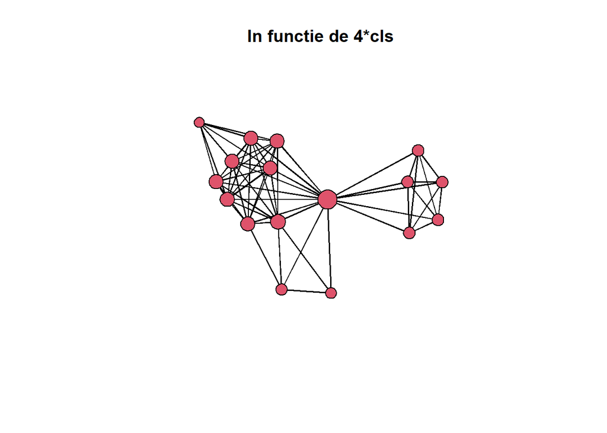

```r
plot(Bali,usearrows=FALSE,vertex.cex=4*cls, main="In functie de 4*cls")
```

Un alt exemplu interesant este dat de proprietatea betweenness, denumita in continuare “bet”. In acest caz, valorile difera foarte multe, diferenta dintre nodul cel mai mic si cel mai mare fiind de peste 100. Astfel, o solutie este sa realizam radical din (bet + 1).

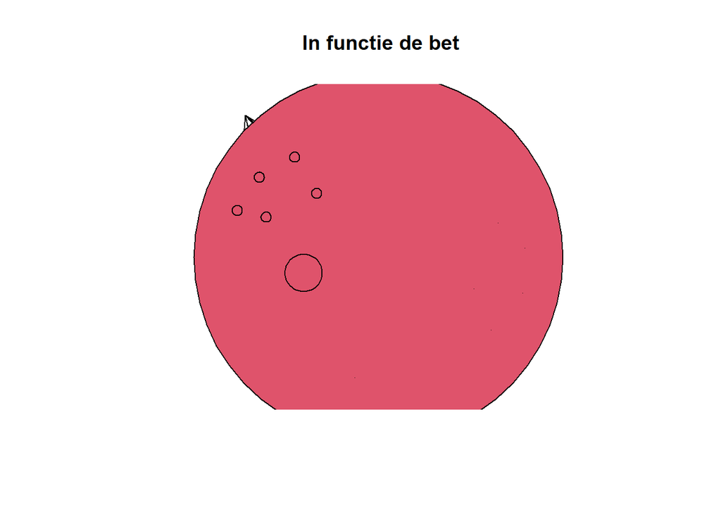

```r
bet <- betweenness(Bali,gmode="graph")
plot(Bali,usearrows=T,vertex.cex=bet, main="In functie de bet")
```

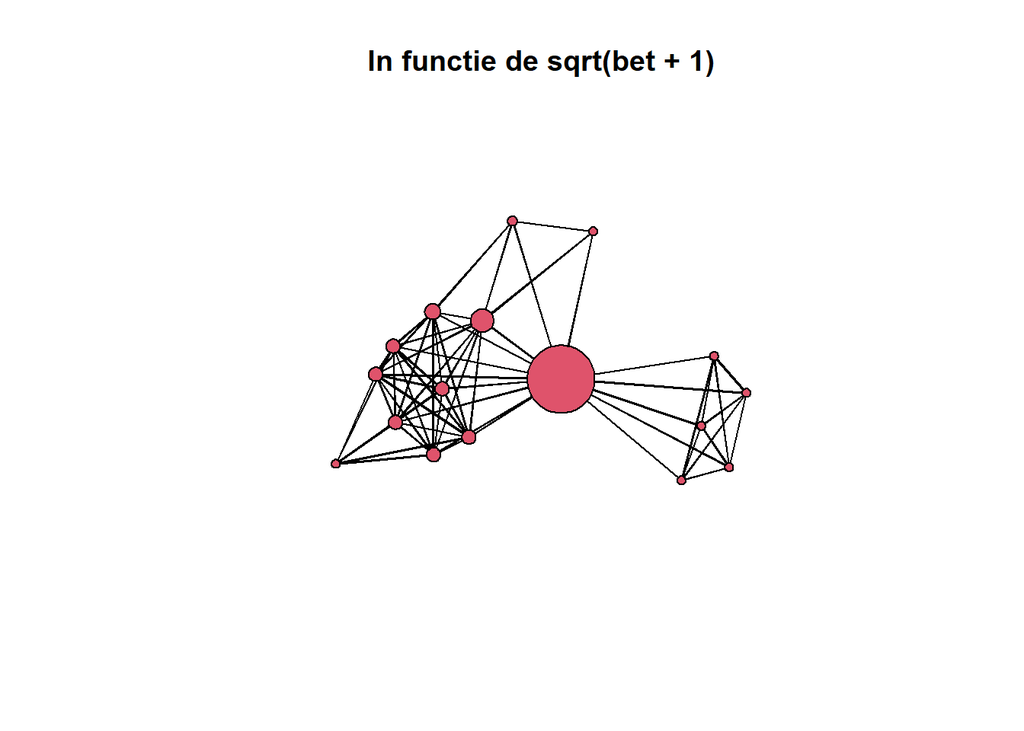

```r
plot(Bali,usearrows=FALSE,vertex.cex=sqrt(bet+1), main="In functie de sqrt(bet + 1)")
```

Uneori nu poate fi foarte usor de intuit in functie de ce proprietate a nodurilor sa facem redimensionarea, sau, mai ales, cum sa prelucram acea proprietate. De aceeea, R vine in ajutor cu o functie **rescale()**, care primeste un vector de caracteristici ale nodurilor si face automat redimensionarea intre o valoare minima “low” si una maxima “high”. Mai jos am ilustrat aplicarea functiei rescale peste vectorul de proprietati “deg” (degree).

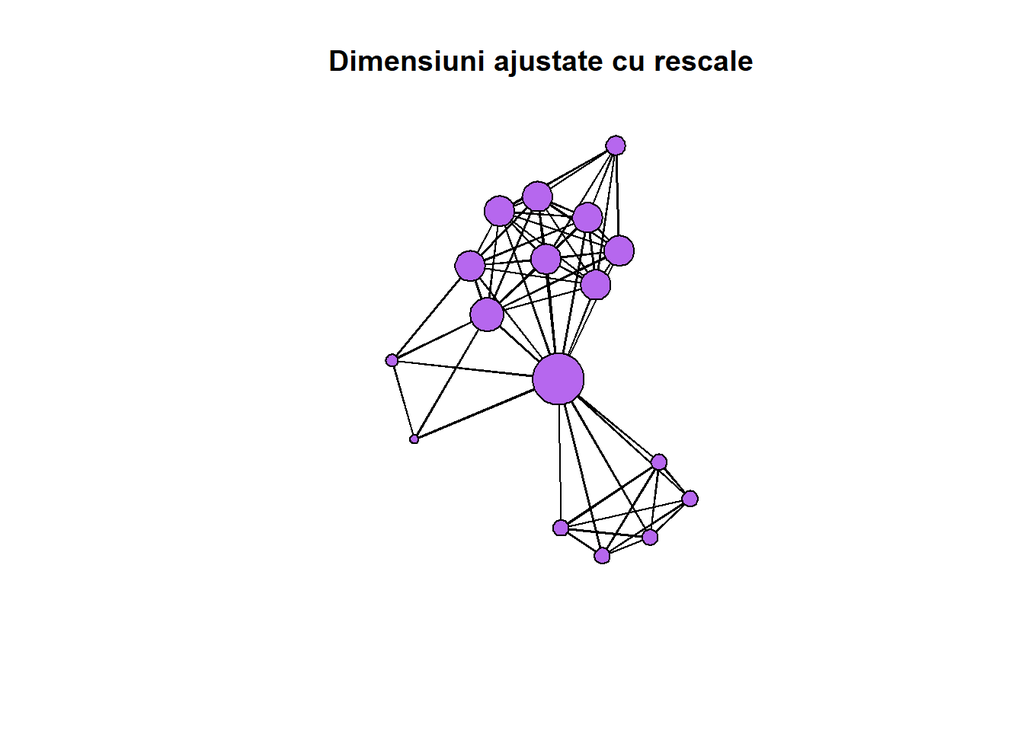

```r
rescale <- function(nchar,low,high) {
min_d <- min(nchar)
max_d <- max(nchar)
rscl <- ((high-low)*(nchar-min_d))/(max_d-min_d)+low
rscl
}

plot(Bali,vertex.col=rgb(182,103,238, maxColorValue=255), vertex.cex=rescale(deg,1,6), main="Dimensiuni ajustate cu rescale")
```

### 5.2.4 Eticheta unui nod

De multe ori este foarte util sa putem vedea ce reprezinta fiecare nod in parte intr-o retea. Acest lucru este posibil prin afisarea unei etichete asociata fiecarui nod. Optiunea **vertex.names** ne ofera aceasta posibilitate.

De asemenea, este suficient sa folosim doar optiunea de **displaylabels=TRUE**:

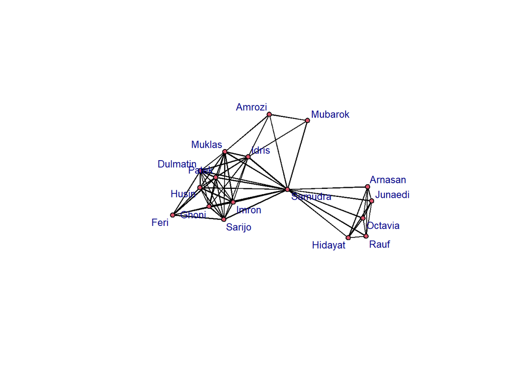

```r
plot(Bali,displaylabels=TRUE,label.cex=0.8, pad=0.4,label.col="darkblue")
```

Un alt exemplu de etichete ar fi cu o proprietate utila, aleasa de noi pentru afisare. Spre exemplu, in cazul setului de date Bali, este mai util sa stim rolul infractorilor, decat numele acestora. De aceea, am preluat in variabila **rolelab** vectorul ce contine rolul fiecarui nod din retea:

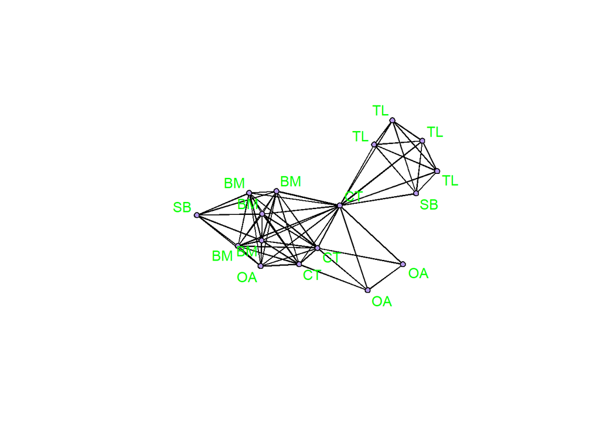

```r
rolelab <- get.vertex.attribute(Bali,"role")
plot(Bali, vertex.col=rgb(182,153,238, maxColorValue=255), usearrows=FALSE,label=rolelab, displaylabels=T,label.col="green")
```

### 5.2.5 Grosimea unei muchii

Daca reteaua contine informatii legate de ce se afla intre noduri, atunci un mod intuitiv de a transmite acest lucru este prin trasarea mai pronuntata a muchiilor respective, facandu-le mai groase sau mai subtiri (**edge.lwd**). Cateva exemple: puterea/vechimea unei prietenii, cantitatile de bani transmise intre anumite companii, etc.

Un exemplu sugestiv din acest punct de vedere pentru reteaua Bali este dat de nivelul de interactiune dintre membrii retelei (stocat in atributul IC).

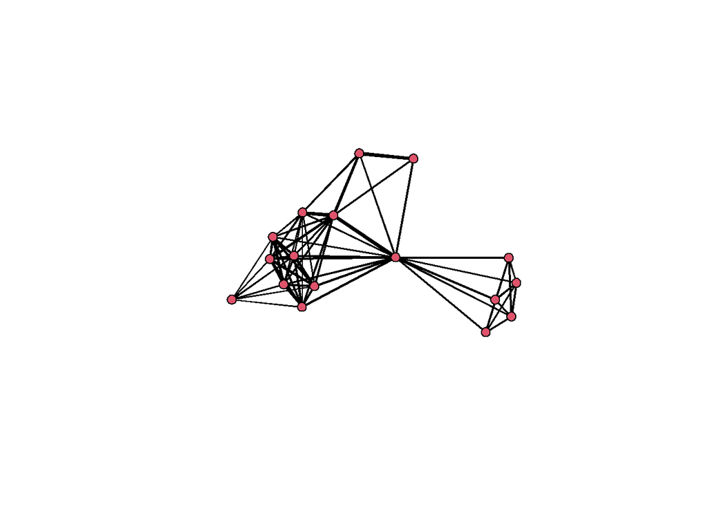

```r
IClevel <- Bali %e% "IC"
plot(Bali,vertex.cex=1.5, edge.lwd=1.5*IClevel)
```

### 5.2.6 Culoarea unei muchii

Culoarea unei muchii (**edge.col**) ne poate transmite informatii precum categoria sau natura relatiei dintre doua noduri. Spre exemplu, putem ilustra daca o prietenie/interactiune este negativa sau pozitiva. Reteaua Bali nu ofera implicit o astfel de impartire pe categorii, insa pentru a ilustra conceptul, vom considera urmatoarele: muchii albastre - relatii neutre, muchii rosii - relatii negative, muchii verzi - relatii pozitive.

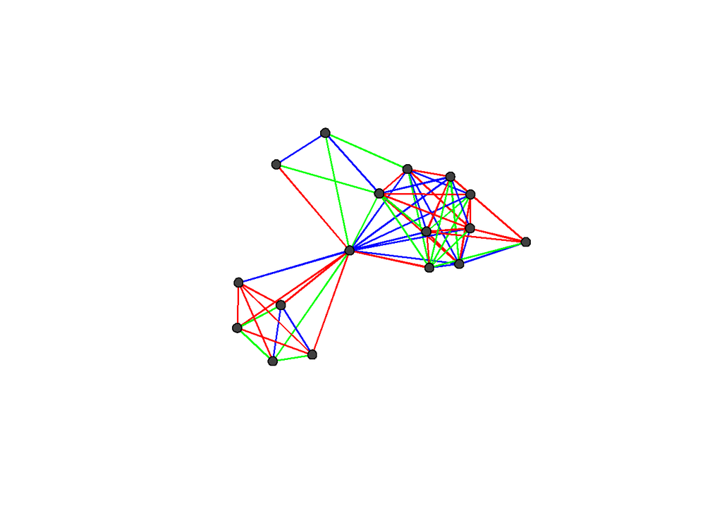

```r
n_edge <- network.edgecount(Bali)
edge_cat <- sample(1:3,n_edge,replace=T)
linecol_pal <- c("blue","red","green")
plot(Bali,vertex.cex=1.5,vertex.col="grey25", edge.col=linecol_pal[edge_cat],edge.lwd=2)
```

### 5.2.7 Tipul de reprezentare al unei muchii

Similar culorii unei muchii, tipul de reprezentare al muchiei(**edge.lty**) ne poate sugera natura legaturii dintre doua noduri. Acelasi exemplu cu relatii negative sau pozitive este valid si in cazul acesta. Mai jos se regaseste un exemplu in care muchiile sunt reprezentate fie cu linie punctata, fie cu linie intrerupta, fie cu linie intrerupta cu puncte.

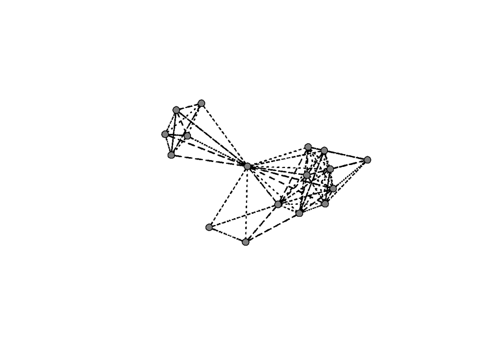

```r
n_edge <- network.edgecount(Bali)
edge_cat <- sample(1:3,n_edge,replace=T)
line_pal <- c(2,3,4)
gplot(Bali,vertex.cex=0.8,gmode="graph", vertex.col="gray50",edge.lwd=1.5, edge.lty=line_pal[edge_cat])
```

Pentru a nu incarca figura se recomanda utilizarea diferitelor tipuri de reprezentare a muchiilor doar in cazul retelelor mici, altfel, se recurge la utilizarea culorilor diferite pentru muchii.

### 5.2.8 Legenda

Chiar si daca ne folosim de diverse elemente grafice, precum cele prezentate mai sus, o legenda poate veni in ajutor, pentru a sintetiza informatiile esentiale. Pachetul statnet nu ofera posibilitatea de a reprezenta legende, insa R dispune de functia **legend()**, care e foarte utila in acest sens.

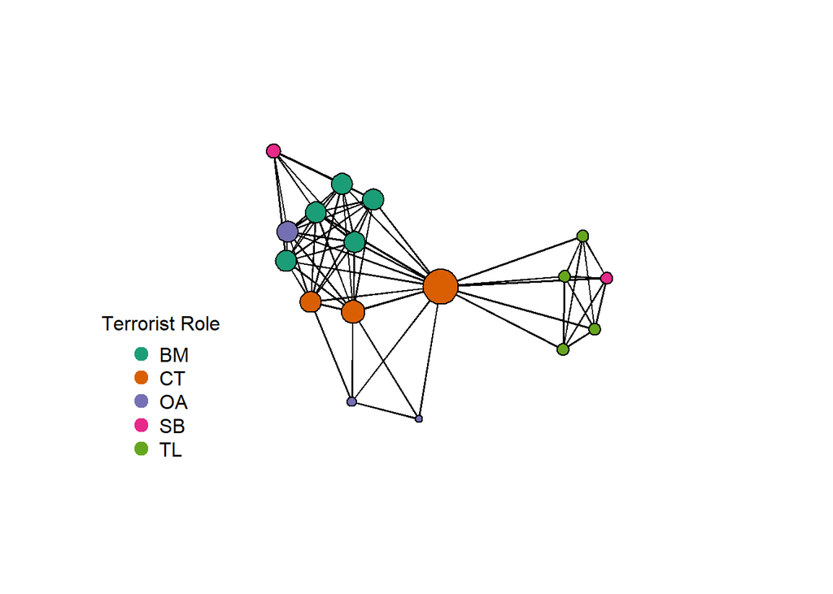

```r
my_pal <- brewer.pal(5,"Dark2")
rolecat <- as.factor(get.vertex.attribute(Bali,"role"))
plot(Bali,vertex.cex=rescale(deg,1,5), vertex.col=my_pal[rolecat])
legend("bottomleft",legend=c("BM","CT","OA","SB","TL"), col=my_pal,pch=19,pt.cex=1.5,bty="n", title="Terrorist Role")
```

In figura de mai sus am folosit atat culori din paleta “Dark2”, cat si dimensiuni diferite pentru ilustrarea nodurilor. Aceste elemente se completeaza perfect cu legenda din coltul stang, unde sunt specificate rolurile asociate fiecarei culori.

## **6. Grafica avansata pentru reprezentarea retelelor**

Elementele grafice prezentate anterior, desi ajuta la transmiterea eficienta a informatiilor unei retele, nu sunt suficiente pentru anumite nevoi si cerinte analitice. Figurile obtinute cu ajutorul pachetelor statnet si igraph sunt complexe, insa statice. In continuare vom analiza posibilitatea de a realiza diagrame interactive, cu care utilizatorul sa poata interactiona.

## 6.1 Elemente de design interactiv

Exista cateva pachete in R care faciliteaza realizarea de diagrame interactive, oferindu-i utilizatorului control asupra explorarii retelei.

### 6.1.1 Retele interactive simple in igraph

Pachetul **igraph** ofera functia **tkplot()** care ajuta la trasarea unei retele interactive, in care utilizatorul poate modifica pozitia nodurilor.

Cu ajutorul urmatoarelor linii de cod am generat o fereastra interactiva in care se pot aranja nodurile retelei in ce fel doreste utilizatorul.

```r
iBali <- asIgraph(Bali)
Coord <- tkplot(iBali, vertex.size=3, vertex.label=V(iBali)$role, vertex.color="darkgreen")
```

Dupa personalizarea reprezentarii grafice din interfata interactiva, am salvat coordonatele nodurilor si le-am reprezentat intr- versiune finala, cu ajutorul **functiei plot**:

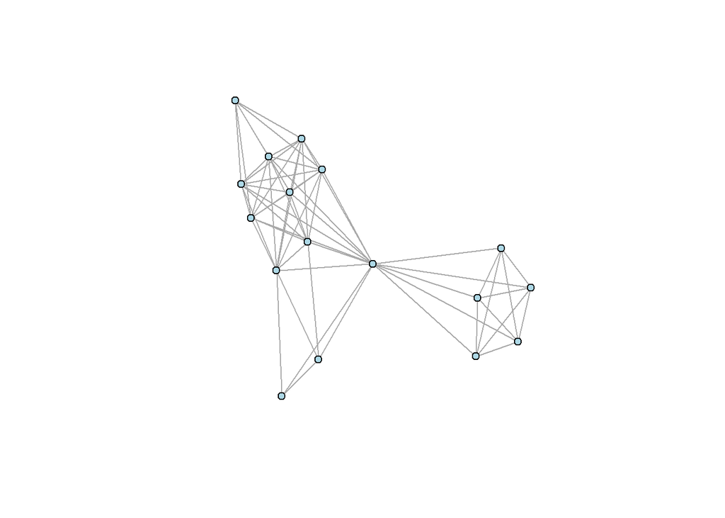

```r
MCoords <- tkplot.getcoords(Coord)
plot(iBali, layout=MCoords, vertex.size=5, vertex.label=NA, vertex.color="lightblue")
```

### 6.1.2 Publicarea unei diagrame interactive in format web

Pachetul **networkD3** prezinta un set de functii cu care putem construi diagrame interactive, pe care le putem salva sub forma unor documente HTML. Functia **simpleNetwork()** preia ca parametru lista de muchii, stocata ca dataframe.

```r
src <- c("A","A","B","B","C","E")
target <- c("B","C","C","D","B","C")
net_edge <- data.frame(src, target)
simpleNetwork(net_edge)
```

[interactive chart not shown]

Pentru a salva figura sub forma unui document HTML, am folosit comanda:

```
net_D3 <- simpleNetwork(net_edge)
saveNetwork(net_D3,file = 'Net_test1.html', selfcontained=TRUE)
```

O functie care poate genera reprezentari mai complexe este **forceNetwork()**. Pentru a o putea apela, trebuie sa trimitem parametrii sub forma a doua dataframe-uri: primul va contine lista de muchii, iar al doilea lista de noduri, alaturi de id-urile si proprietatile lor. Numerotarea id-urilor nodurilor incepe de la 0. O singura variabila de categorii este permisa.

```r
iBali <- asIgraph(Bali)
#construim lista de muchii:
iBali_edge <- get.edgelist(iBali)
iBali_edge <- iBali_edge - 1
iBali_edge <- data.frame(iBali_edge)

#construim lista de noduri:
iBali_nodes <- data.frame(NodeID=as.numeric(V(iBali)-1), Group=V(iBali)$role, Nodesize=(degree(iBali)))

forceNetwork(Links = iBali_edge, Nodes = iBali_nodes, Source = "X1", Target = "X2", NodeID = "NodeID", Nodesize = "Nodesize", radiusCalculation="Math.sqrt(d.nodesize)*3", Group = "Group", opacity = 0.8, legend=TRUE)
```

[interactive chart not shown]

Pachetul **visNetwork** este, de asemenea, foarte util pentru grafica interactiva. Datele trebuie trimise la fel ca la functia forceNetwork(), sub forma de dataframe-uri. Conventia este ca dataframe-ul de noduri sa contina obligatoriu o coloana “id”, dataframe-ul de muchii trebuie sa aiba campurile “from” si “to”.

```r
library(visNetwork)
iBali_edge <- get.edgelist(iBali)
iBali_edge <- data.frame(from = iBali_edge[,1],
to = iBali_edge[,2])
iBali_nodes <- data.frame(id = as.numeric(V(iBali)))
visNetwork(iBali_nodes, iBali_edge, width = "100%")
```

[interactive chart not shown]

Aceste reprezentari interactive se deschid intr-o fereastra in RStudio. Pentru a-l salva intr-un fisier separat, pentru a putea fi refolosit din nou, se poate salva cu ajutorul functiei **saveWidget()**:

```
net <- visInteraction(net,navigationButtons = TRUE)
library(htmlwidgets)
saveWidget(net, "My_interactive_graph.html")
```

### 6.1.3 Statnet web: statnet interactiv

Cu ajutorul framework-ului shiny, echipa de dezvoltare statnet a creat o versiune web a tool-urilor lor de analiza de retele. Utilizatorul poate crea graph-ul dorit dintr-o interfata primitoare, selectand parametrii si optiuni din elemente de drop-down.

### 6.2 Diagrame de retea specializate

Diagramele de retele sunt utile pentru a ilustra proprietati esentiale ale retelei si ale nodurilor. Totusi, sunt disponibile si alte tipuri de diagrame, precum: diagrame cu arcuri, diagrame coarda si heatmap-uri.

### 6.2.1 Diagrame cu arcuri

Atunci când modelul legăturilor într-o rețea este mai important decât locația nodurilor, pot fi folosite diagrame cu arc. Pentru acest lucru avem nevoie de libraria **gastonstat/arcdiagram**, de pe github.

Functia **arcplot** este cea care creeaza diagrama. Aceasta primeste ca parametru lista de muchii. Mai jos s-a folosit setul de date Simpsons.

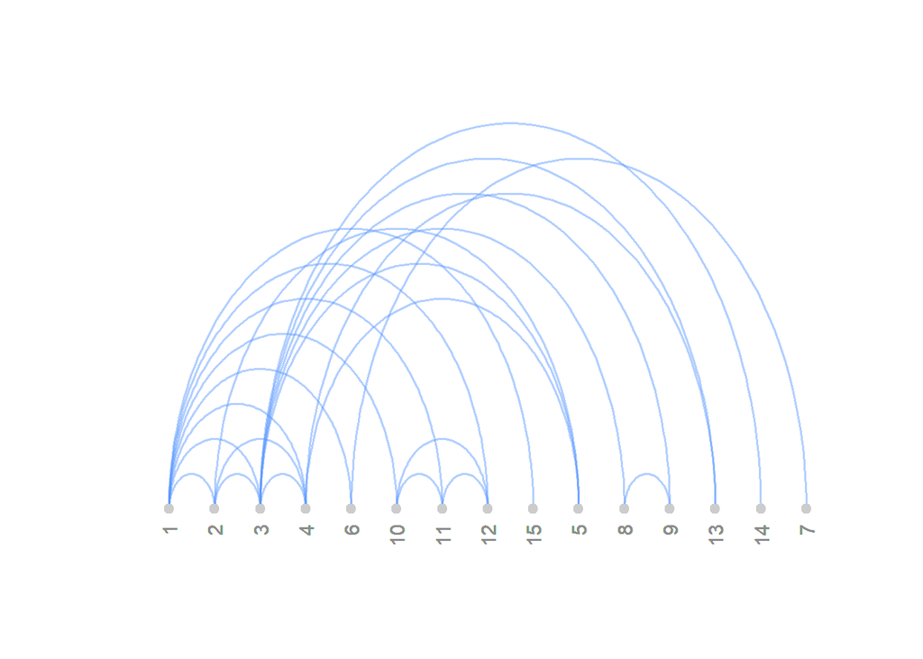

```r
data(Simpsons)
iSimp <- asIgraph(Simpsons)
simp_edge <- get.edgelist(iSimp)
arcplot(simp_edge)
```

Diagrama poate fi personalizata in felul urmator: vom imparti datele in grupurile urmatoare: 1=familie, 2=munca, 3=scoala, 4=vacini, iar pentru fiecare categorie se vor folosi culori diferite.

[figure not shown]

```r
s_grp <- V(iSimp)$group
s_col = c("#a6611a", "#dfc27d","#80cdc1","#018571")
cols = s_col[s_grp]
node_deg <- degree(iSimp)
arcplot(simp_edge, lwd.arcs=2, cex.nodes=node_deg/2, labels=V(iSimp)$vertex.names, col.labels="darkgreen",font=1, pch.nodes=21,line=1,col.nodes = cols, bg.nodes = cols, show.nodes = TRUE)
```

### 6.2.2 Diagrame coarda

Diagramele coarda sunt un fel special de reprezentare grafica circulara a datelor dintr-un tabel, in care se pune accentul pe afisarea relatiilor dintre date. Cum retelele se pot stoca si sub forma de tabel, acest tip de diagrama devine o varianta optima si pentru reprezentarea grafica a retelelor. Se recomanda folosirea lor in cazurile in care retelele prezinta informatie chiar pe muchii (weighted) si informatia respectiva este mai de interes decat alte informatii ale nodurilor.

Pachetul **circlize** dispune de o multime de diagrame circulare, printre care si diagrama coarda. Vom folosi setul de date “2010 Netherlands World Cup soccer team”, ca sa analizam numarul de pasari de minge intre membrii echipei.

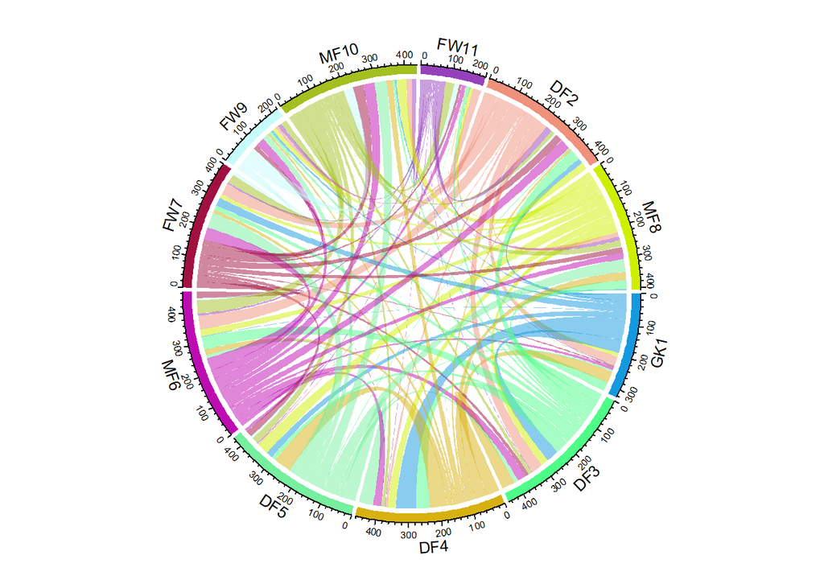

```r
library(statnet)
library(circlize)
data(FIFA_Nether)
FIFAm <- as.sociomatrix(FIFA_Nether,attrname='passes')
names <- c("GK1","DF3","DF4","DF5","MF6",
"FW7","FW9","MF10","FW11","DF2","MF8")
rownames(FIFAm) = names
colnames(FIFAm) = names
chordDiagram(FIFAm)
```

Uneori poate fi dificil de interpretat diagramele coarda, motiv pentru care se recomanda sa finisam diagrama. De aceea, pentru diagrama de mai jos, am impartit jucatorii in categorii desemnate de aceeasi culoare (Forward=albastru, Midfielder=verde, etc). De asemenea, am setat optiunea de bidirectional=true, pentru a se putea observa cu usurinta de la cine a venit mingea, si catre cine a plecat.

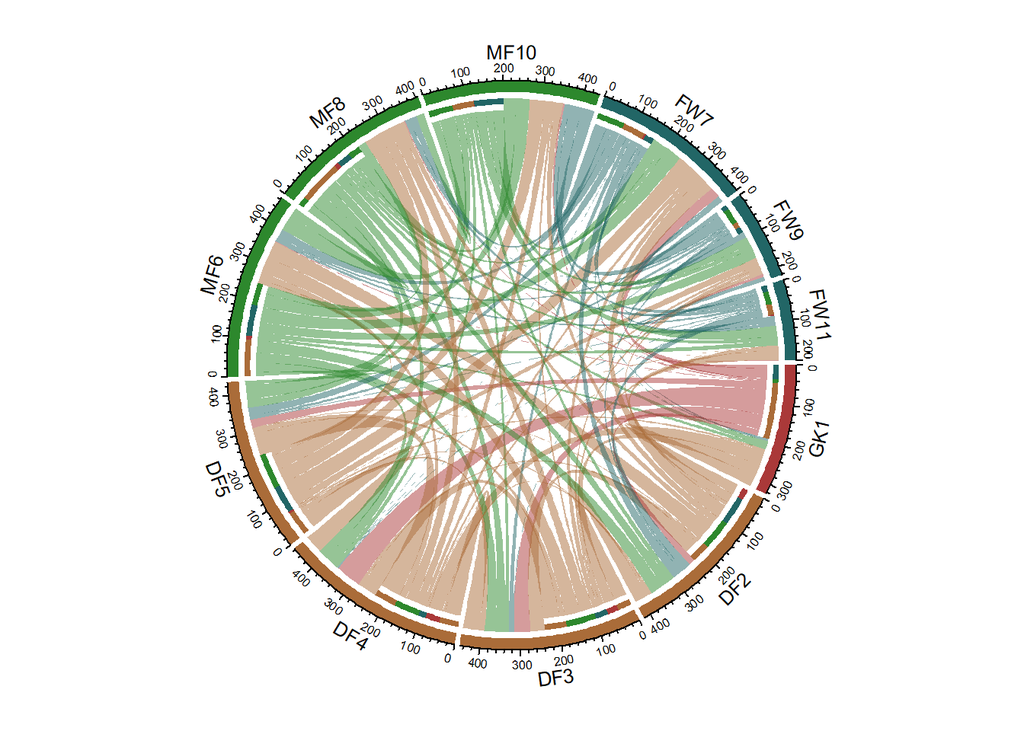

```r
data(FIFA_Nether)
FIFAm <- as.sociomatrix(FIFA_Nether,attrname='passes')
names <- c("GK1","DF3","DF4","DF5","MF6",
"FW7","FW9","MF10","FW11","DF2","MF8")
rownames(FIFAm) = names
colnames(FIFAm) = names
grid.col <- c("#AA3939",rep("#AA6C39",4), rep("#2D882D",3),rep("#226666",3))
chordDiagram(FIFAm,directional = TRUE,
grid.col = grid.col, order=c("GK1","DF2","DF3","DF4","DF5", "MF6","MF8","MF10","FW7", "FW9","FW11"))
```

### 6.2.3 Heatmaps

Heatmap-urile sunt alt tip de diagrame potrivite pentru retelele cu informatie pe muchii (weighted). In cazul setului de date FIFA_Nether, aceasta diagrama ne ajuta pentru a determina care sunt jucatorii care au dat si care au primit cele mai multe pasari de minge.

La fel ca in cazul diagramelor coarda, datele trebuie organizate sub forma unei matrici sociomatrix, care contine numarul de pasari de minge pentru fiecare jucator:

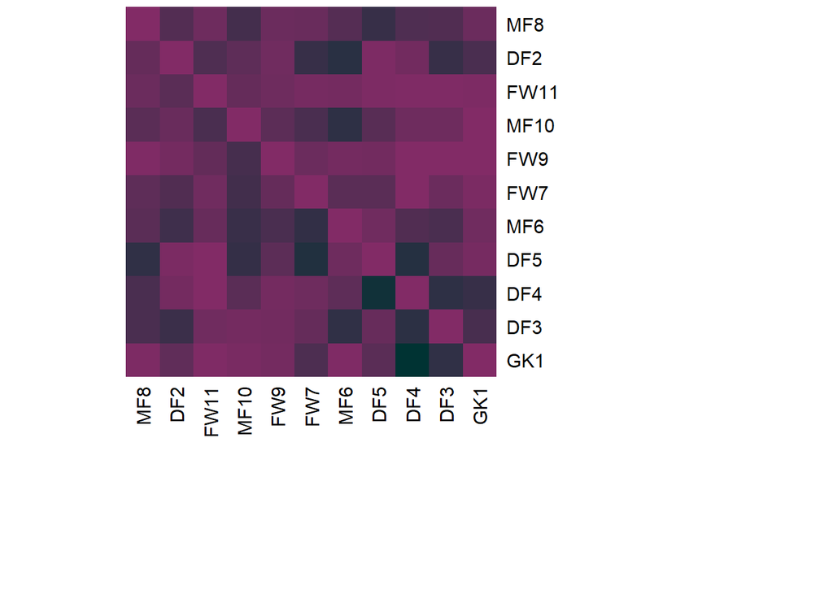

```r
data(FIFA_Nether)
FIFAm <- as.sociomatrix(FIFA_Nether,attrname='passes')
colnames(FIFAm) <- c("GK1","DF3","DF4","DF5", "MF6","FW7","FW9","MF10", "FW11","DF2","MF8")
rownames(FIFAm) <- c("GK1","DF3","DF4","DF5", "MF6","FW7","FW9","MF10", "FW11","DF2","MF8")
palf <- colorRampPalette(c("#822B66", "#003333"))
heatmap(FIFAm[,11:1],Rowv = NA,Colv = NA,col = palf(60),
scale="none", margins=c(11,11) )
```

In figura de mai sus, jucatorii de pe linii sunt cei care trimit mingea (passers), iar cei de pe coloana sunt cei care o primesc (receivers). Astfel, cea mai intunecata casuta este cea care desemneaza faptul ca GK1 a dat cele mai multe mingi catre DF4.

## 6.3 Crearea de diagrame de retele cu alte pachete R

### 6.3.1 Diagrame realizate cu ggplot2

Desi acest pachet nu este cel mai potrivit pentru realizarea unei reprezentari complexe a unei retele, iata ce optiuni ofera: functia edgeMaker() este folosita pentru a crea grafice atractive folosing curba de intensitate conică.

```r
fifa <- FIFA_Nether

edgeMaker <- function(whichRow,len=100, curved = TRUE){
  fromC <- layoutCoordinates[adjacencyList[whichRow,1],]
  toC <- layoutCoordinates[adjacencyList[whichRow,2],]
  graphCenter <- colMeans(layoutCoordinates)
  bezierMid <- c(fromC[1], toC[2])
  distance1 <- sum((graphCenter - bezierMid)**2)
if(distance1 < sum((graphCenter - c(toC[1], fromC[2]))**2)){
  bezierMid <- c(toC[1], fromC[2])
}
bezierMid <- (fromC + toC + bezierMid) / 3
if(curved == FALSE){
  bezierMid <- (fromC + toC) / 2
}
edge <- data.frame(bezier(c(fromC[1], bezierMid[1], toC[1]), c(fromC[2], bezierMid[2], toC[2]), evaluation = len))
edge$Sequence <- 1:len
edge$Group <- paste(adjacencyList[whichRow, 1:2], collapse = ">")
return(edge)
}

fifa <- FIFA_Nether
fifa.edge <- as.edgelist.sna(fifa,attrname='passes')
fifa.edge <- data.frame(fifa.edge)
names(fifa.edge)[3] <- "value"
fifa.edge <- fifa.edge[fifa.edge$value > 9,]
adjacencyList <- fifa.edge
```

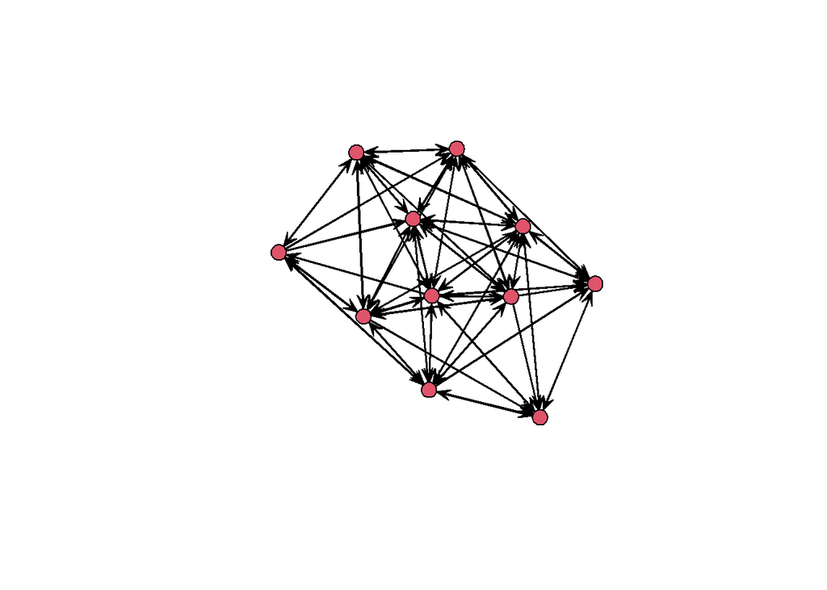

```r
layoutCoordinates <- gplot(network(fifa.edge))
```

```r
allEdges <- lapply(1:nrow(fifa.edge),
edgeMaker, len = 500, curved = TRUE)
allEdges <- do.call(rbind, allEdges)
```

Înainte de a finaliza graficul, adaugam o noua temă ggplot.

```r
new_theme_empty <- theme_bw()
new_theme_empty$line <- element_blank()
new_theme_empty$rect <- element_blank()
new_theme_empty$strip.text <- element_blank()
new_theme_empty$axis.text <- element_blank()
new_theme_empty$plot.title <- element_blank()
new_theme_empty$axis.title <- element_blank()
new_theme_empty$plot.margin <- structure(c(0,0,-1,-1),unit = "lines",valid.unit = 3L,class = "unit")
```

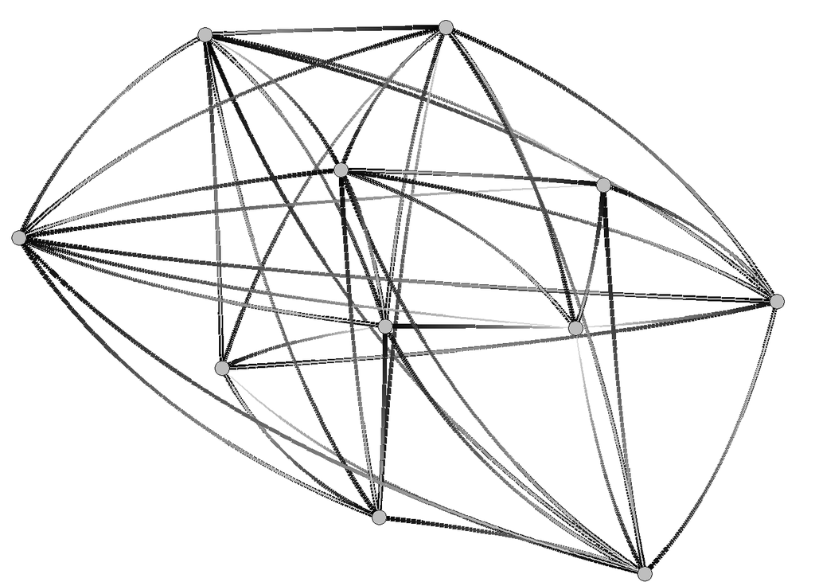

```r
zp1 <- ggplot(allEdges)
zp1 <- zp1 + geom_path(aes(x = x, y = y, group = Group,colour=Sequence, size=-Sequence))
zp1 <- zp1 + geom_point(data = data.frame(layoutCoordinates),aes(x = x, y = y),size = 4, pch = 21,colour = "black", fill = "gray")
zp1 <- zp1 + scale_colour_gradient(low = gray(0),high = gray(9/10),guide = "none")
zp1 <- zp1 + scale_size(range = c(1/10, 1.5),guide = "none")
zp1 <- zp1 + new_theme_empty
print(zp1)
```